# UK Retail Store Sales History

Project3 / Data1001 / 30/10 2023

Guohan Fu 520034369

2023-10-30

# Client:

Vivienne Westwood https://www.viviennewestwood.com/

British designer label founded by fashion designer Vivienne Westwood.

As of December 2015, Vivienne Westwood Ltd operated 12 retail stores in the UK, including an outlet store in Bicester Village. There were 63 Westwood shops worldwide including nine in China, nine in Hong Kong, 18 in South Korea, six in Taiwan, two in Thailand, and two in the United States.

# Recommendation

# Evidence

The variables that should be reviewed in order to validate the recommendation are: View product quantity over a specific period of time (e.g., each month). See how product prices change as the month progresses. Check out which months there are high-priced products for sale. [The Data Source](https://www.kaggle.com/datasets/gabrielramos87/an-online-shop-business)

```r
uksale = uk_retail %>% filter(Country == 'United Kingdom')
library(lubridate)
uksale$Month = month(mdy(uksale$Date))
uksale$Month = factor(uksale$Month)
```

### What is the relationship between the month and price in the past year in United Kingdom?

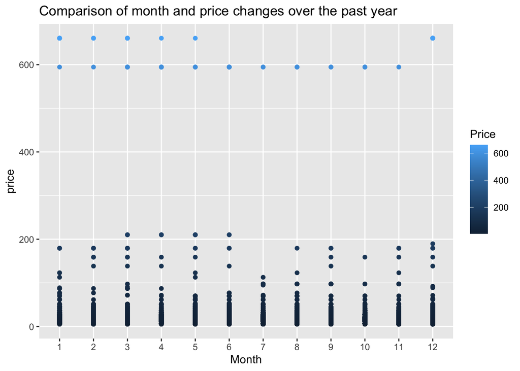

```r
library(ggplot2)
ggplot(data = uksale) +
  geom_point(aes(x = Month, y = Price, color = Price)) +
  labs(x = 'Month',y = 'price',title = "Comparison of month and price changes over the past year")
```

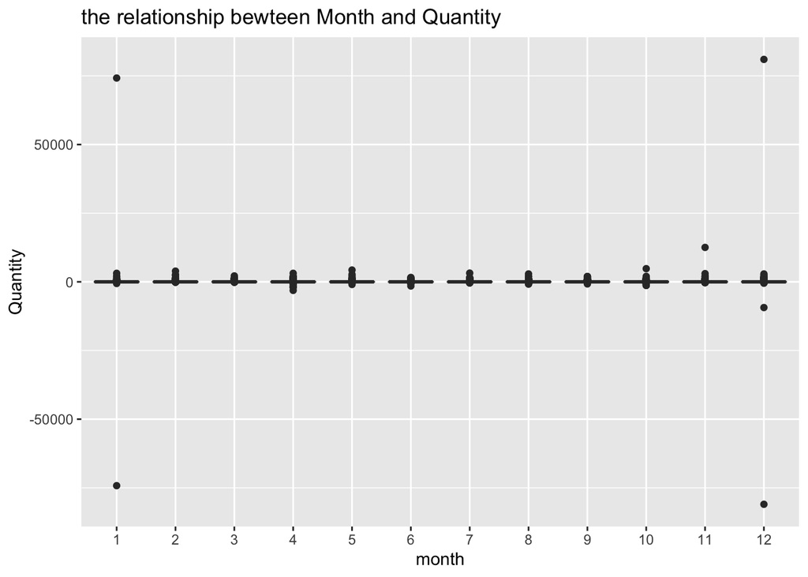

```r
ggplot(data = uksale) +
  geom_boxplot(aes(x = Month, y = Quantity, fill = Quantity))+
  labs(x = 'month', y = 'Quantity', title = 'the relationship bewteen Month and Quantity' )
```

As you can see from the figure, the average of each month’s sales is close to zero, fluctuating up and down near zero, but two extreme points up and down exist in each of the months of January and December. However, This figure is not very precise, the client can only notice the large sales and losses, so in order to provide the client with accurate information, this report frames a range for the figure.

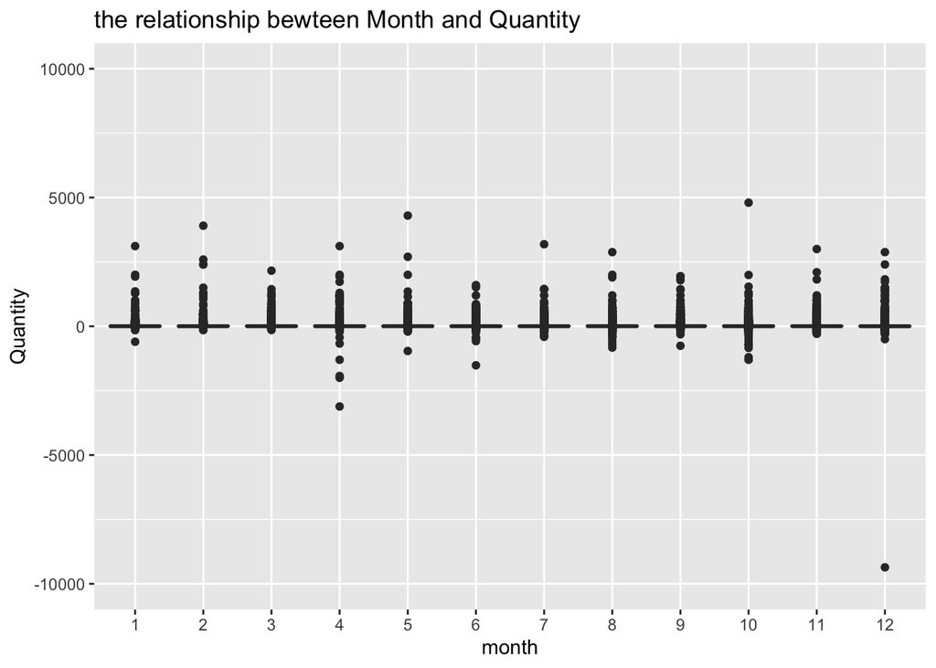

```r
ggplot(data = uksale) +
  geom_boxplot(aes(x = Month, y = Quantity, fill = Quantity))+
  labs(x = 'month', y = 'Quantity', title = 'the relationship bewteen Month and Quantity' )+
  coord_cartesian(ylim = c(-10000,10000))
```

This figure is much clearer and you can see greater fluctuations in the data from month to month, with April having a significant drop in quantity, possibly due to a build-up of goods as well as back orders.May and October had good quantity, both topping out at close to $5,000.

# Acknowledgements

-Grolemund, G. (n.d.). Hands-on programming with R. D Loading and Saving Data in R. https://rstudio-education.github.io/hopr/dataio.html -Wikimedia Foundation. (2023, October 15). Vivienne Westwood. Wikipedia. https://en.wikipedia.org/wiki/Vivienne_Westwood#Vivienne_Westwood_companies -Awan, A. A. (2023, March 14). T-tests in R tutorial: Learn how to conduct t-tests. DataCamp. https://www.datacamp.com/tutorial/t-tests-r-tutorial

# Appendix

## Customer Choice

I chose the Vivienne Westwood because it’s a localised jewellery brand that originated in the UK, and figures such as sales volume and price have a big impact on them, and changes over time are often accompanied by changes in other variables. Therefore I offer them a range of possible suggestions. Based on my knowledge of the Vivienne Westwood, I prefer to analyse a wide range of information and data by focusing on specific contexts.

## Analysis

```r
t.test(uksale$Price, uksale$Quantity)
```

```
##
##  Welch Two Sample t-test
##
## data:  uksale$Price and uksale$Quantity
## t = 10.909, df = 486475, p-value < 2.2e-16
## alternative hypothesis: true difference in means is not equal to 0
## 95 percent confidence interval:
##  2.922972 4.203351
## sample estimates:
## mean of x mean of y
## 12.653651  9.090489
```

## limitation

Admittedly, there are some limitations to this report, as the factors affecting quantity and prices are not only month and region, but also other external factors, such as market fluctuations or price increases.